# 市场观察

2017/07/17

## A、指数估值

### (a1)动态市盈率、市净率

核心指数成分股近18个月的动态市盈率及动态市净率中位数走势如下图所示：

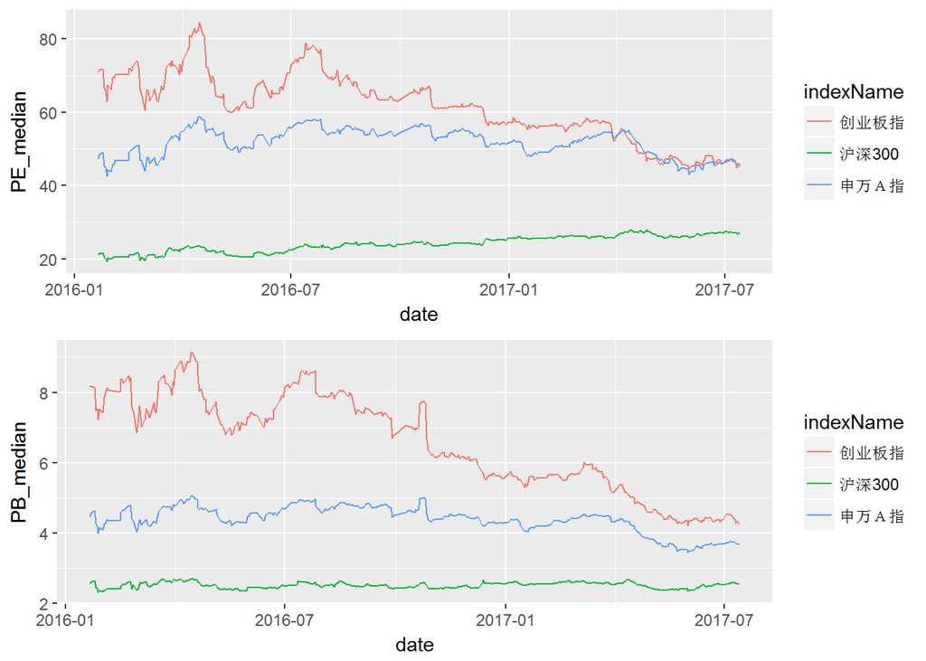

### (a2)动态市盈率、市净率百分位

核心指数近18个月的动态市盈率百分位及动态市净率百分位走势如下图所示：

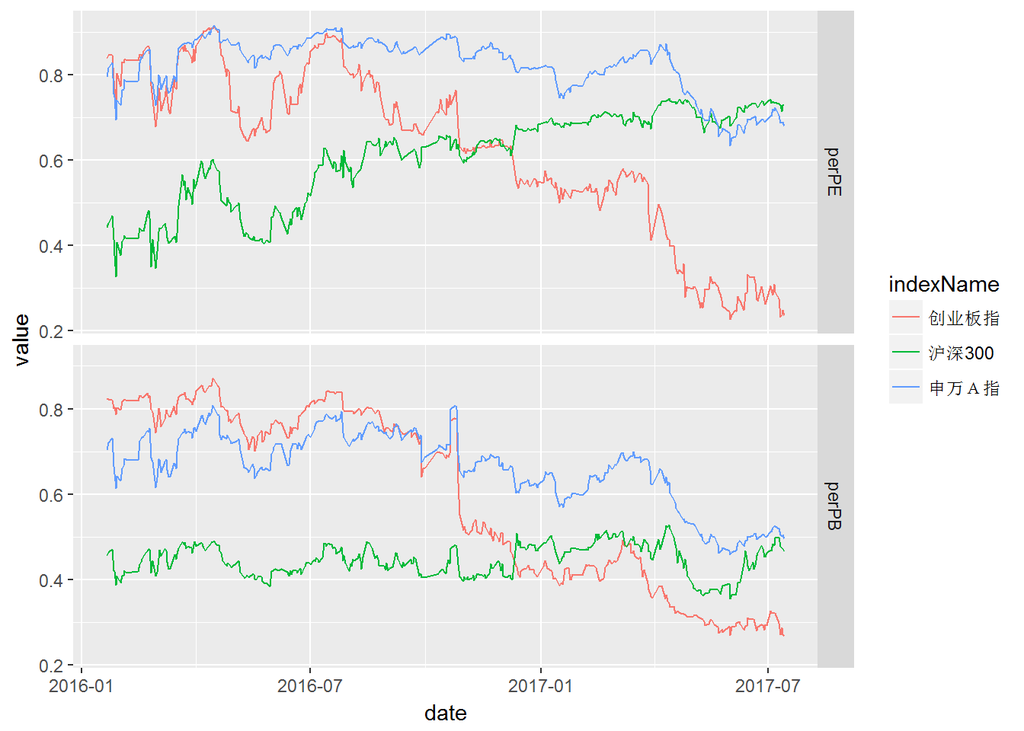

### (a3)指数估值概览

纳入观察的指数最新的估值情况如下表，根据市盈率和市净率分位数均值降序排列。

| 指数代码 | 指数简称 | 日期 | 动态市盈率 | 市盈率百分位 | 动态市净率 | 市净率百分位 |
| --- | --- | --- | --- | --- | --- | --- |
| EI000819 | 有色金属 | 2017-07-14 | 63.5 | 86% | 3.4 | 56% |
| EI000979 | 大宗商品 | 2017-07-14 | 38.2 | 72% | 2.6 | 55% |
| EI000300 | 沪深300 | 2017-07-14 | 27.1 | 73% | 2.5 | 47% |
| EI801003 | 申万Ａ指 | 2017-07-14 | 45.6 | 68% | 3.7 | 50% |
| EI399330 | 深证100 | 2017-07-14 | 33.2 | 69% | 3.5 | 44% |
| EI399959 | 军工指数 | 2017-07-14 | 81.0 | 54% | 4.0 | 50% |
| EI399005 | 中小板指P | 2017-07-14 | 38.2 | 53% | 4.4 | 37% |
| EI000905 | 中证500 | 2017-07-14 | 36.8 | 51% | 2.9 | 32% |
| EI000934 | 中证金融 | 2017-07-14 | 19.5 | 66% | 1.7 | 12% |
| EI000016 | 上证50 | 2017-07-14 | 17.3 | 56% | 1.6 | 18% |
| EI000998 | 中证TMT | 2017-07-14 | 40.8 | 35% | 3.7 | 30% |
| EI000922 | 中证红利 | 2017-07-14 | 16.2 | 38% | 1.7 | 27% |
| EI000932 | 中证消费 | 2017-07-14 | 30.9 | 43% | 3.7 | 22% |
| EI000827 | 中证环保 | 2017-07-14 | 35.1 | 26% | 3.1 | 28% |
| EI399006 | 创业板指 | 2017-07-14 | 45.2 | 24% | 4.2 | 27% |
| EI000933 | 中证医药 | 2017-07-14 | 33.1 | 24% | 3.7 | 4% |

### (a4)另类估值

我国10年期国债收益率、金银比价、金油比价，2000年以来的历史百分位如下图所示：

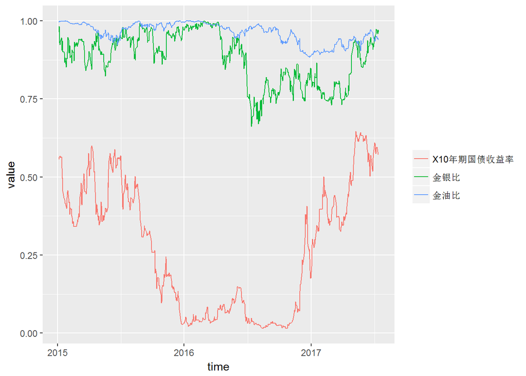

## B、基差及市场情绪

### (b1)基差走势

三大股指期货合约基差走势如下图，其中当月合约和次月合约年化基差百分比波动较大，仅展示合约基差百分比，当季合约和次季合约展示基差年化百分比：

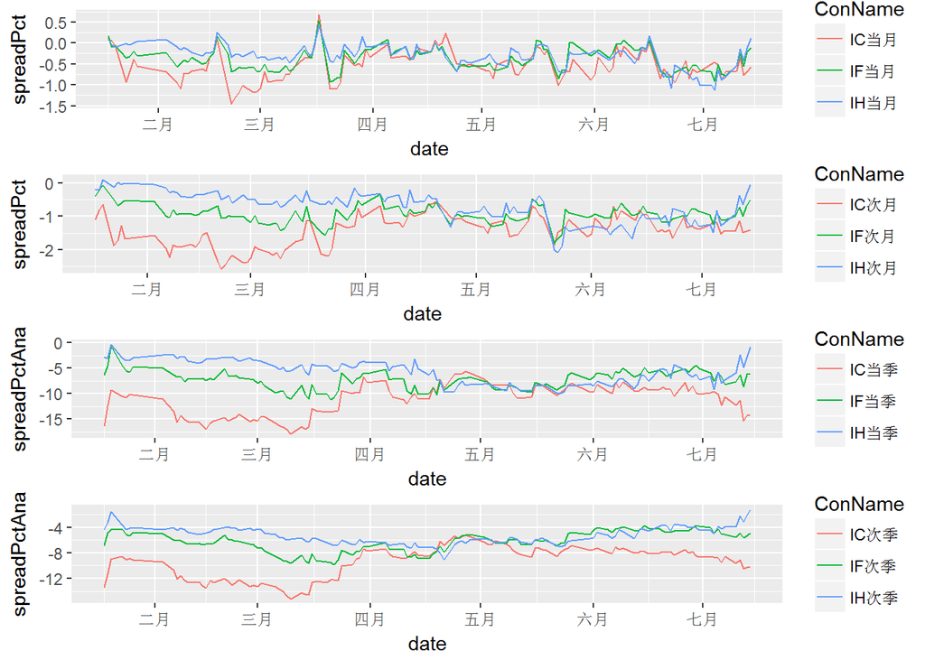

### (b2)基差概况

三大股指期货连续合约基差概况如下表，近月合约临近到期日，年化基差百分比数据波动较大：

| 日期 | 合约代码 | 合约收盘价 | 指数收盘价 | 基差 | 基差百分比 | 年化基差百分比 |
| --- | --- | --- | --- | --- | --- | --- |
| 2017-07-14 | IC1707 | 6093.4 | 6128.7 | -35.3 | -0.6% | -35.0% |
| 2017-07-14 | IC1708 | 6042.6 | 6128.7 | -86.1 | -1.4% | -15.7% |
| 2017-07-14 | IC1709 | 5987.0 | 6128.7 | -141.7 | -2.3% | -14.2% |
| 2017-07-14 | IC1712 | 5871.2 | 6128.7 | -257.5 | -4.2% | -10.2% |
| 2017-07-14 | IF1707 | 3698.8 | 3703.1 | -4.3 | -0.1% | -6.2% |
| 2017-07-14 | IF1708 | 3684.4 | 3703.1 | -18.7 | -0.5% | -5.4% |
| 2017-07-14 | IF1709 | 3664.2 | 3703.1 | -38.9 | -1.1% | -6.2% |
| 2017-07-14 | IF1712 | 3627.4 | 3703.1 | -75.7 | -2.0% | -4.9% |
| 2017-07-14 | IH1707 | 2626.2 | 2623.0 | 3.2 | 0.1% | 6.6% |
| 2017-07-14 | IH1708 | 2622.0 | 2623.0 | -1.0 | -0.0% | -0.4% |
| 2017-07-14 | IH1709 | 2619.2 | 2623.0 | -3.8 | -0.1% | -0.8% |
| 2017-07-14 | IH1712 | 2609.8 | 2623.0 | -13.2 | -0.5% | -1.2% |

### (b3)市场情绪(provided by han.qian)

市场情绪记录近60天每天自然涨跌停(剔除一字板)、创60日新高新低、多头排列空头排列(均线组合5,30,60,120)的股票数。

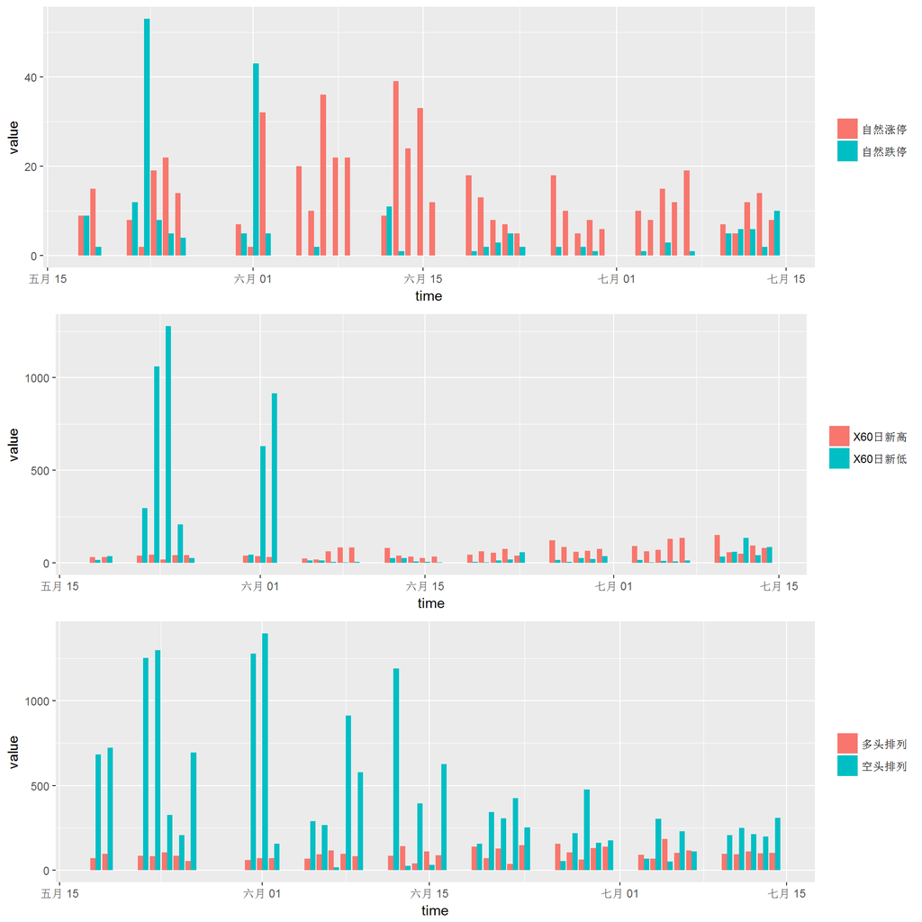

## C、套利和事件

### (c1)复牌股票套利

近两天复牌股票套利情况如下表：

[1] “No Arbitrage!”

### (c2)定增基金(provided by han.qian)

定增基金数据如下表，明细数据参见钱瀚的模板。

| 代码 | 名称 | 到期日期 | 最新净值 | 昨日收盘价 | 折溢价率 | 整体隐含折价率 | 大盘下跌0.1净值变化 |
| --- | --- | --- | --- | --- | --- | --- | --- |
| 168101.OF | 九泰锐智 | 20200814 | 1.16 | 0.97 | -16.2% | 4.2% | -10.2% |
| 168102.OF | 九泰锐富 | 20210204 | 1.00 | 0.79 | -20.6% | 2.8% | -5.8% |
| 501015.OF | 财通升级 | 20170908 | 0.97 | 0.93 | -4.8% | 0.3% | -9.3% |
| 160518.OF | 博时睿远 | 20171016 | 0.97 | 0.91 | -5.8% | 0.5% | -7.0% |

定增基金近期的净值走势如下图：

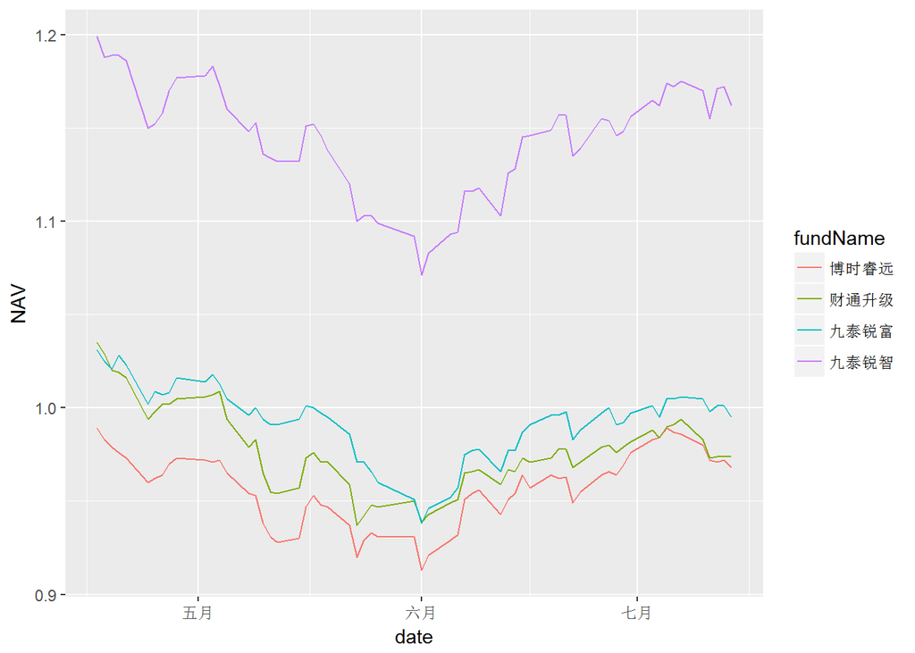

定增基金近期的折溢价率百分比走势如下图：

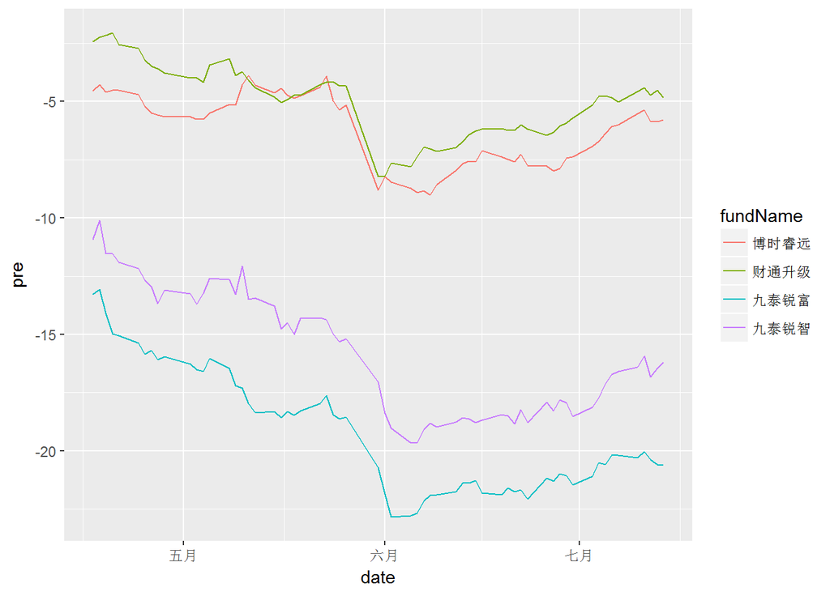

### (c3)解禁

解禁分成两个部分，定增解禁和IPO解禁，涨跌幅记录是过去十个交易日的股票涨跌幅和对应行业指数涨跌幅。伴随着去年下半年IPO逐步正常化，今后IPO解禁给市场造成的抛压会持续存在，所以纳入观察。近期定增解禁的股票情况如下表。

| 股票代码 | 股票简称 | 解禁日 | 解禁数量 | 解禁百分比 | 区间涨跌幅 | 所属行业指数 | 行业指数涨跌幅 |
| --- | --- | --- | --- | --- | --- | --- | --- |
| EQ300274 | 阳光电源 | 2017-07-18 | 2.16 | 26% | -4.3% | 申万电气设备 | -0.5% |
| EQ600179 | 安通控股 | 2017-07-19 | 0.91 | 23% | -2.0% | 申万交通运输 | 0.9% |
| EQ002620 | 瑞和股份 | 2017-07-19 | 0.62 | 26% | -14.7% | 申万建筑装饰 | 1.7% |
| EQ300317 | 珈伟股份 | 2017-07-20 | 0.57 | 22% | 3.7% | 申万电气设备 | -0.5% |
| EQ603939 | 益丰药房 | 2017-07-21 | 0.43 | 27% | 0.2% | 申万医药生物 | -3.0% |
| EQ002718 | 友邦吊顶 | 2017-07-24 | 0.05 | 24% | 1.5% | 申万建筑材料 | 2.2% |
| EQ600483 | 福能股份 | 2017-07-24 | 9.70 | 336% | -3.1% | 申万公用事业 | -3.5% |
| EQ002594 | 比亚迪 | 2017-07-25 | 2.52 | 28% | 1.1% | 申万汽车 | -1.2% |
| EQ000408 | 藏格控股 | 2017-07-27 | 0.61 | 24% | -1.5% | 申万商业贸易 | -0.6% |
| EQ000040 | 东旭蓝天 | 2017-07-28 | 5.94 | 127% | 1.0% | 申万房地产 | -0.3% |
| EQ600864 | 哈投股份 | 2017-07-28 | 5.02 | 92% | -0.4% | 申万非银金融 | 4.1% |
| EQ002157 | 正邦科技 | 2017-07-31 | 4.96 | 36% | -0.6% | 申万农林牧渔 | -0.6% |

近期IPO解禁的股票情况如下表。

| 股票代码 | 股票简称 | 解禁日 | 解禁数量 | 解禁百分比 | 区间涨跌幅 | 所属行业指数 | 行业指数涨跌幅 | 上市日 |
| --- | --- | --- | --- | --- | --- | --- | --- | --- |
| EQ603009 | 北特科技 | 2017-07-18 | 0.72 | 132% | 2.0% | 申万汽车 | -1.2% | 2014-07-18 |
| EQ300490 | 华自科技 | 2017-07-18 | 0.41 | 82% | -15.2% | 申万电气设备 | -0.5% | 2015-12-31 |
| EQ300517 | 海波重科 | 2017-07-19 | 0.16 | 62% | -8.3% | 申万建筑装饰 | 1.7% | 2016-07-19 |
| EQ002806 | 华锋股份 | 2017-07-26 | 0.44 | 129% | 0.0% | 申万有色金属 | 7.4% | 2016-07-26 |
| EQ300525 | 博思软件 | 2017-07-26 | 0.26 | 154% | -6.4% | 申万计算机 | -3.4% | 2016-07-26 |
| EQ300523 | 辰安科技 | 2017-07-26 | 0.67 | 186% | -2.0% | 申万计算机 | -3.4% | 2016-07-26 |
| EQ603322 | 超讯通信 | 2017-07-28 | 0.12 | 62% | -8.9% | 申万通信 | -1.5% | 2016-07-28 |
| EQ300389 | 艾比森 | 2017-07-31 | 2.25 | 242% | -5.2% | 申万电子 | -0.8% | 2014-08-01 |
| EQ300384 | 三联虹普 | 2017-07-31 | 0.91 | 171% | -5.9% | 申万计算机 | -3.4% | 2014-08-01 |
| EQ002728 | 特一药业 | 2017-07-31 | 1.35 | 223% | -6.4% | 申万医药生物 | -3.0% | 2014-07-31 |
| EQ603126 | 中材节能 | 2017-07-31 | 3.92 | 180% | 0.0% | 申万公用事业 | -3.5% | 2014-07-31 |
| EQ300390 | 天华超净 | 2017-07-31 | 1.50 | 113% | -4.0% | 申万电子 | -0.8% | 2014-07-31 |

### (c4)中小板业绩预增预测(provided by han.qian)

中小板规定正式财务报告发布的同时需要发布新一期的业绩预报，比如年报中会包含一季报预告的情况。我们假设公司的盈利状况有动量效应，年报预增的公司一季度也会预增，在正式财务报告发布前20个交易日开始埋伏，然后等正式报告发布日卖出。具体研究参见钱瀚前期的研究。需要注意的是这里的收益率仅做展示，仅仅是每日全部入选股票的平均收益率，并没有做成一个事件组合。

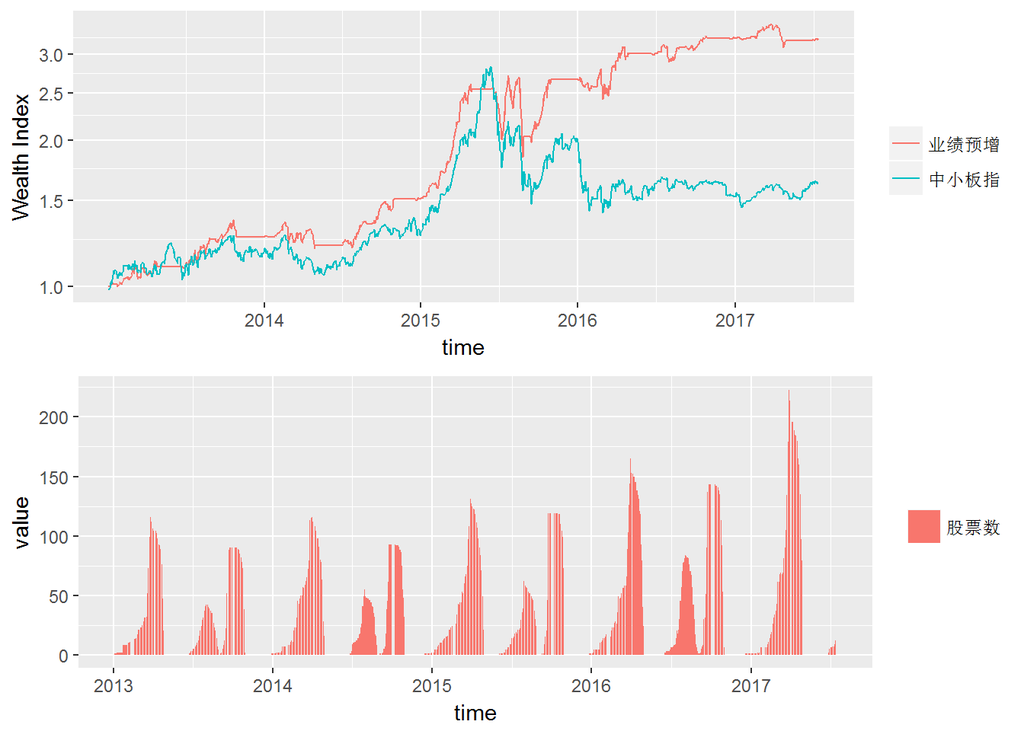

历年收益统计如下表所示。

|  | 业绩预增 | 中小板指 |
| --- | --- | --- |
| 2013-01-04 ~ 2013-12-31 | 26.4% | 17.5% |
| 2014-01-02 ~ 2014-12-31 | 19.9% | 9.7% |
| 2015-01-05 ~ 2015-12-31 | 76.0% | 53.7% |
| 2016-01-04 ~ 2016-12-30 | 21.8% | -22.9% |
| 2017-01-03 ~ 2017-07-14 | -0.3% | 6.9% |
| Cumulative Return | 224.0% | 63.3% |
| Annualized Return | 29.6% | 11.4% |